# Task_20160522-20160523

Upon a visit a random delay timer of {1.5s, 2.5, 3.5} starts then a light cue appears for 0.9s within the time of the light cue it is possible to open the door with a nosepoke, otherwise it counts as a time error{with no negative reinforcement sound}.

On the 22th Mice {2,5,9} recived 10uL per gram of saline(i.e if a mouse weighs 25g it recived 250uL of saline) through intraperitoneal injection. Mice {4,6,13} recived 10mg/Kg CNO.

On the 23th Mice {4,6,13} recived 10uL per gram of saline(i.e if a mouse weighs 25g it recived 250uL of saline) through intraperitoneal injection. Mice {2,5,9} recived 10mg/Kg CNO.

This R markdown requires ggplot2 package and will install it if it doesn't exist.

It read the “animals.txt”, “visits.txt” and “nosepokes.txt” files, removes all non-first nosepokes

and assigns animal name for each event as a factor(visit and nosepoke).

This is the visit count with the appropriate plot

```
##
## Animal 13  Animal 2  Animal 4  Animal 5  Animal 6  Animal 9
##       228       226       192       306       232       232
```

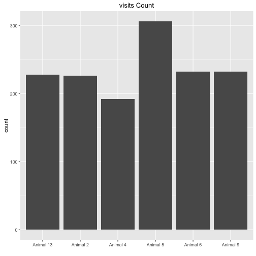

Visits over time for each animal

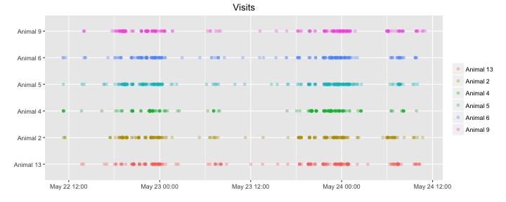

Visit count across absoulute time

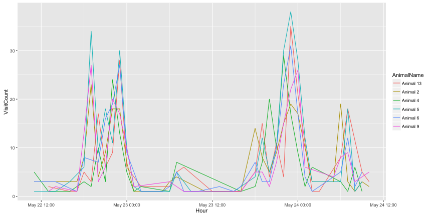

This is the hour with the maximun number of visits

```
## [1] "2016-05-23 23:00:00 IDT"
```

This is the nosepokes count with the appropriate plot

```
##
## Animal 13  Animal 2  Animal 4  Animal 5  Animal 6  Animal 9
##       170       167       162       222       179       172
```

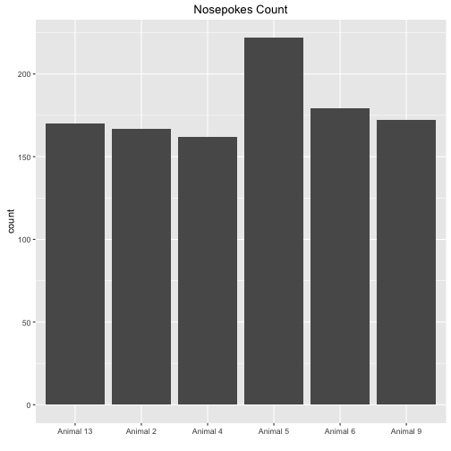

Nosepokes over time for each animal

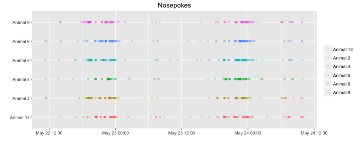

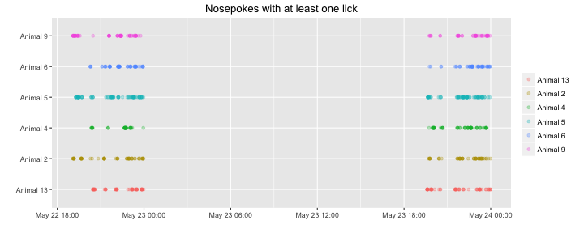

This is a plot showing the amount of nosepokes in the time window per day per animal

[output not shown]

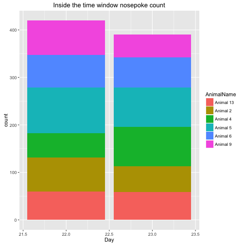

This is a plot showing the fraction of errors per time window per module, the number of the module corresponds the anticipation time in seconds.

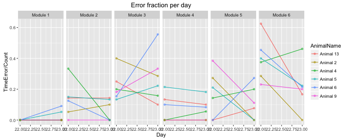

This is an histogram showing the reaction times(values under zero are nosepokes before the light cue) by Day by anticipation time, the salmon colored line is the overall median reaction time:

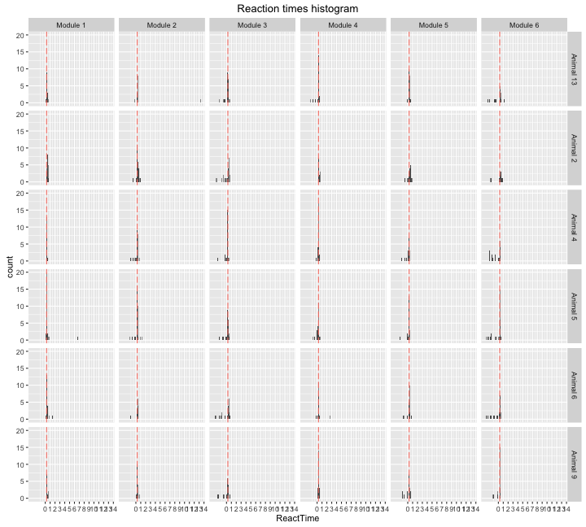

```
## [1] "The median reaction time in seconds:0.279999971389771"
```

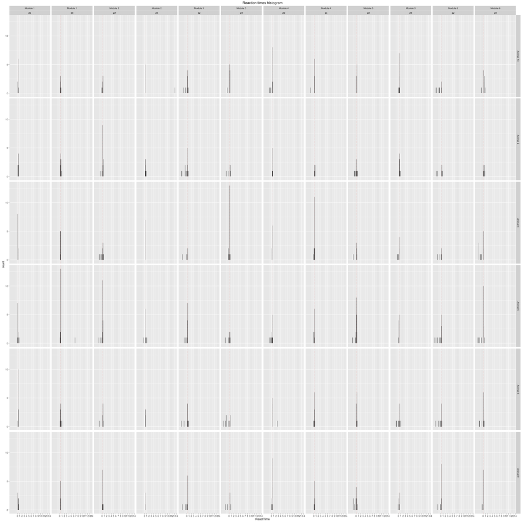

These are the summarized results

```
##    AnimalName Day ModuleName Count TimeError ErrorFraction Injection Sound
## 1   Animal 13  22   Module 5     8         0    0.00000000       CNO    On
## 2    Animal 9  22   Module 5    13         5    0.38461538    Saline    On
## 3    Animal 5  22   Module 5    19         4    0.21052632    Saline    On
## 4    Animal 6  22   Module 5    12         0    0.00000000       CNO    On
## 5    Animal 4  22   Module 5     7         1    0.14285714       CNO    On
## 6    Animal 2  22   Module 5    11         3    0.27272727    Saline    On
## 7   Animal 13  23   Module 5    13         1    0.07692308    Saline    On
## 8    Animal 9  23   Module 5     9         1    0.11111111       CNO    On
## 9    Animal 5  23   Module 5    11         0    0.00000000       CNO    On
## 10   Animal 6  23   Module 5    11         3    0.27272727    Saline    On
## 11   Animal 4  23   Module 5    10         2    0.20000000    Saline    On
## 12   Animal 2  23   Module 5     9         0    0.00000000       CNO    On
## 13  Animal 13  22   Module 3    12         3    0.25000000       CNO   Off
## 14   Animal 9  22   Module 3    11         2    0.18181818    Saline   Off
```

[output cut: 58 more lines]

```
##   Injection Sound      Mean        SEM
## 1       CNO    On 0.1414382 0.04280783
## 2    Saline    On 0.2016482 0.03144462
## 3       CNO   Off 0.1295706 0.02822606
## 4    Saline   Off 0.1091666 0.03587554
```

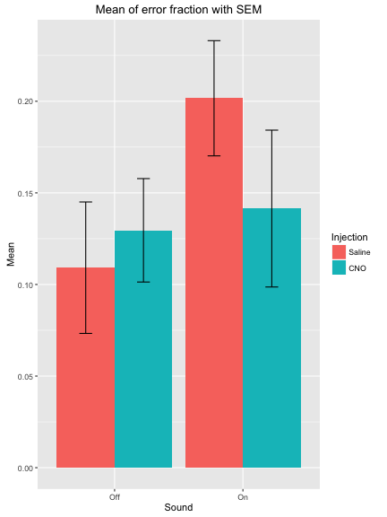

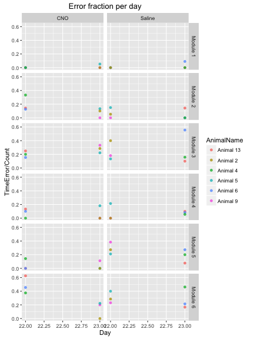